# CEMA 0907: Problem Set 2

## Exercise 1

Find an interesting data visualization on the Internet and provide the URL. http://r-statistics.co/Top50-Ggplot2-Visualizations-MasterList-R-Code.html

### (a)

Describe the variables in the plot, and identify their types.

gdpPercap (X/independent) - number representing the GDP per capita in the data point’s respective country. lifeExpectancy (Y/dependent) - number that represents the life expectancy

### (b)

Describe the components of the Grammar of Graphics relevant to this visualization (data, aesthetic properties, geometric objects).

- Data
  - Populations within different continents and states with varying populations and their associated GDP per capita
- Aesthetic properties
  - X=gdpPercap
  - Y=lifeExpectancy
  - fill=continent
- Labels
  - title=`respective year`
- Geometric objects
  - `geo_point(...)`

### (c)

Critique this data visualization.

- If you *liked* the visualization: What is it doing well?
  - Not too overcrowded; it represents the data at hand with relative simplicity and makes use of changing the colors (using `aes(fill=x)`) of the points to represent different things without adding another layer.
- If you *disliked* the visualization: What would you change?

## Exercise 2

This exercise uses the `gapminder` dataset in the `gapminder` package, which contains information on various countries from 1952 through 2007. Run the following code to extract only the data for 2007; use `gapminder_2007` for this exercise.

```r
gapminder_2007 = gapminder %>%
  filter(year == 2007)
```

```r
View(gapminder_2007)
```

Write code to recreate [Figure 2.1](https://moderndive.com/2-viz.html#fig:gapminder) in *ModernDive* *as close as possible*.

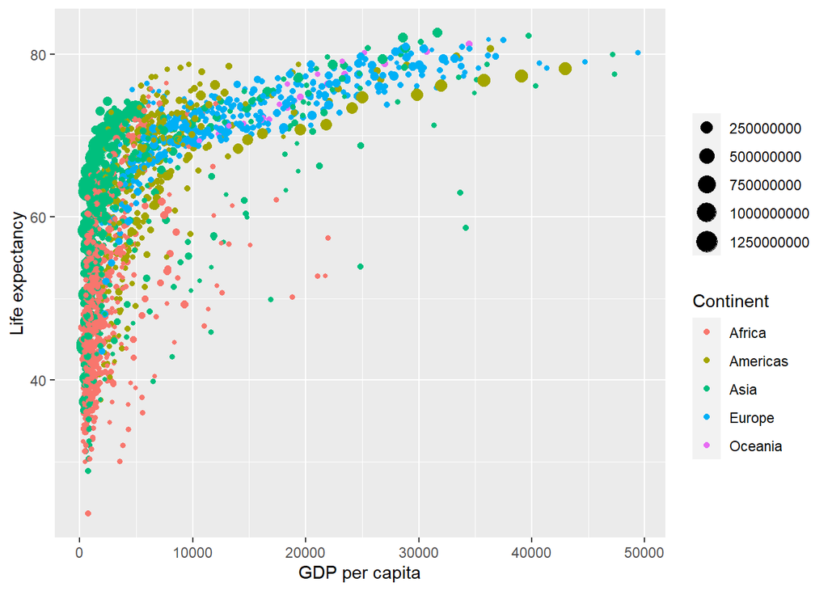

```r
options(scipen=1000000000)
gapminder %>%
  filter(gdpPercap <= 50000) %>%
  ggplot(mapping = aes(x = gdpPercap, y = lifeExp, color = continent, size = pop)) +
  geom_point() +
  labs(x = "GDP per capita", y = "Life expectancy", color = "Continent", size = "")
```

## Exercise 3

These exercises use the `mpg` data from the `ggplot2` package (in the `tidyverse`).

### (a)

Run the following code:

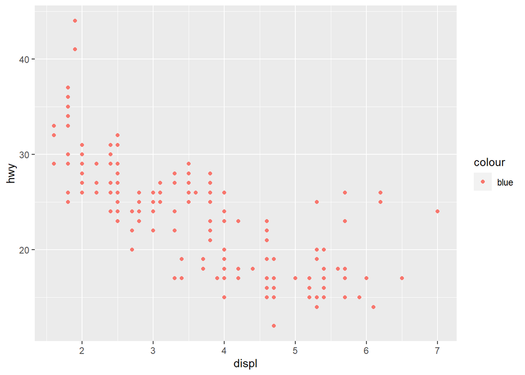

```r
ggplot(data = mpg) +
  geom_point(mapping = aes(x = displ, y = hwy, color = "blue"))
```

Even though the code has `color = "blue"`, explain why the points are not blue.

In order to get them to be blue, this parameter must be specified for `geom_point(…)`, not `aes(…)`.

### (b)

Create a scatterplot of highway miles per gallon (*y*) against engine displacement, in liters (*x*). Map an additional numerical variable to the `color` aesthetic. Explain how this aesthetic behave differently for categorical vs. numerical variables.

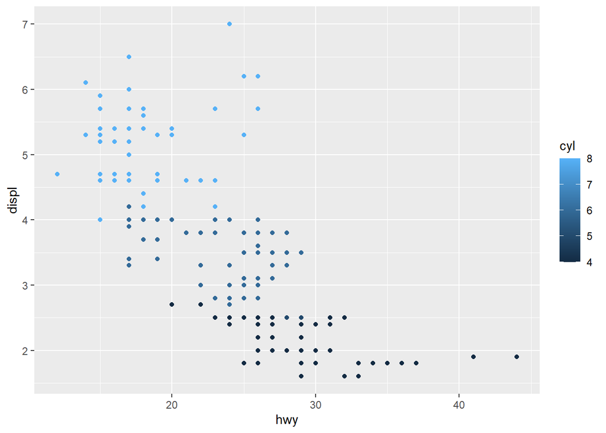

```r
mpg %>%
  ggplot(mapping = aes(x = hwy, y = displ, color = cyl)) +
  geom_point()
```

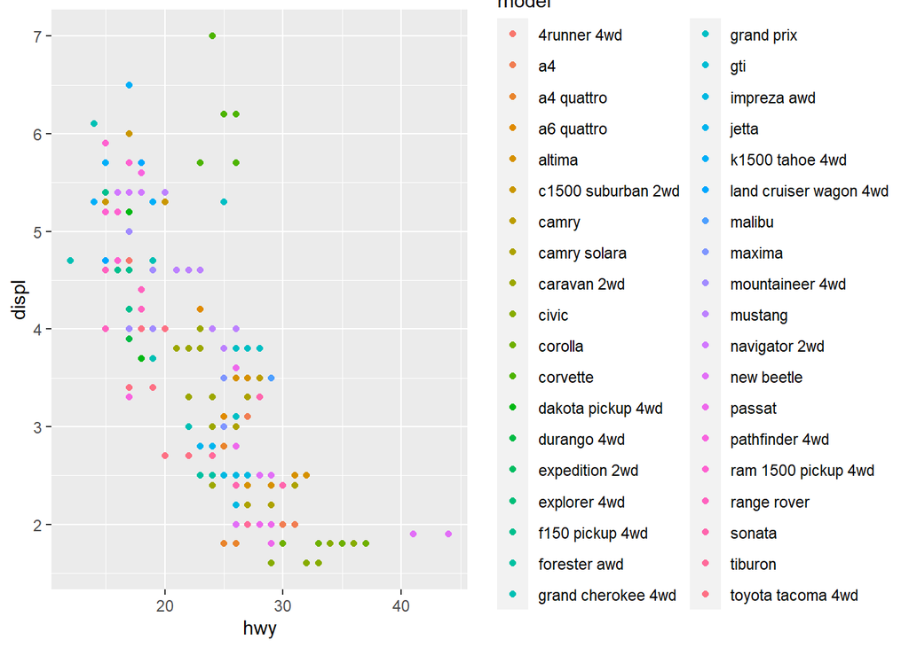

```r
mpg %>%
  ggplot(mapping = aes(x = hwy, y = displ, color = model)) +
  geom_point()
```

When inputting a numerical value for the `color`, it provides a gradient key, while when inputting a non-numeric (categorical) value for the `color`, a key of all the possibilities is provided.

### (c)

Create a scatterplot of highway miles per gallon (*y*) against engine displacement, in liters (*x*), using different-colored points for cars with *at least 20 city miles per gallon* versus cars with *less than 20 city miles per gallon*. [Hint: Do this by mapping the `color` aesthetic to the appropriate *logical* vector.]

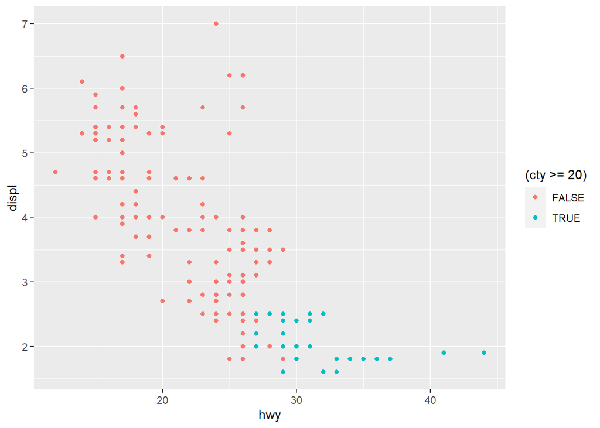

```r
mpg %>%
  ggplot(mapping = aes(x = hwy, y = displ)) +
  geom_point(mapping = aes(color = (cty >= 20)))
```

## Exercise 4

The following exercises use data on board game ratings from the *Board Game Geek* database and the *TidyTuesday* Github repository. Load the data by running the following:

```r
board_games = readr::read_csv("https://raw.githubusercontent.com/rfordatascience/tidytuesday/master/data/2019/2019-03-12/board_games.csv")

# Create categorical 'decade' variable
board_games = board_games %>%
  mutate(decade = factor(floor(year_published / 10) * 10)) %>%
  mutate(decade = paste0(decade, "s"))
```

```r
View(board_games)
```

### (a)

Create an informative and meaningful data graphic using these data.

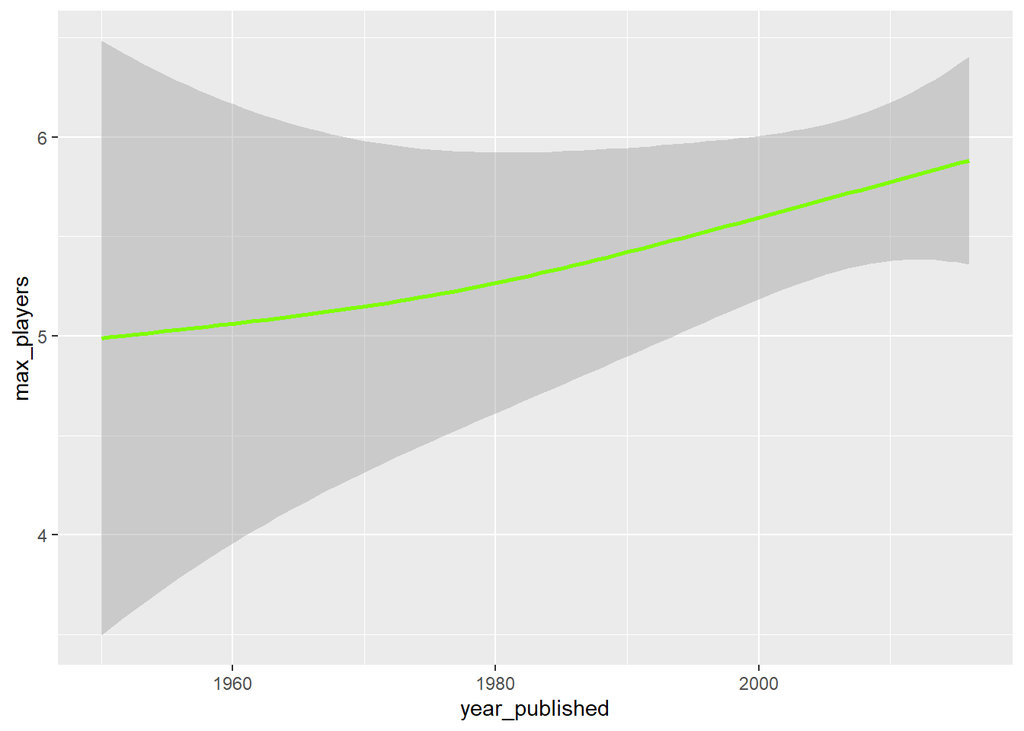

```r
board_games %>%
  ggplot(mapping = aes(x = year_published, y = max_players)) +
  geom_smooth(color = "chartreuse")
```

### (b)

Create a data graphic with at least *four* variables (either quantitative or categorical). For the purposes of this exercise, do not worry about making your visualization meaningful – just try to encode four variables into one plot. [Note: This is *not* good graphical practice – it is merely an exercise to help you understand how to use visual cues and aesthetics!]

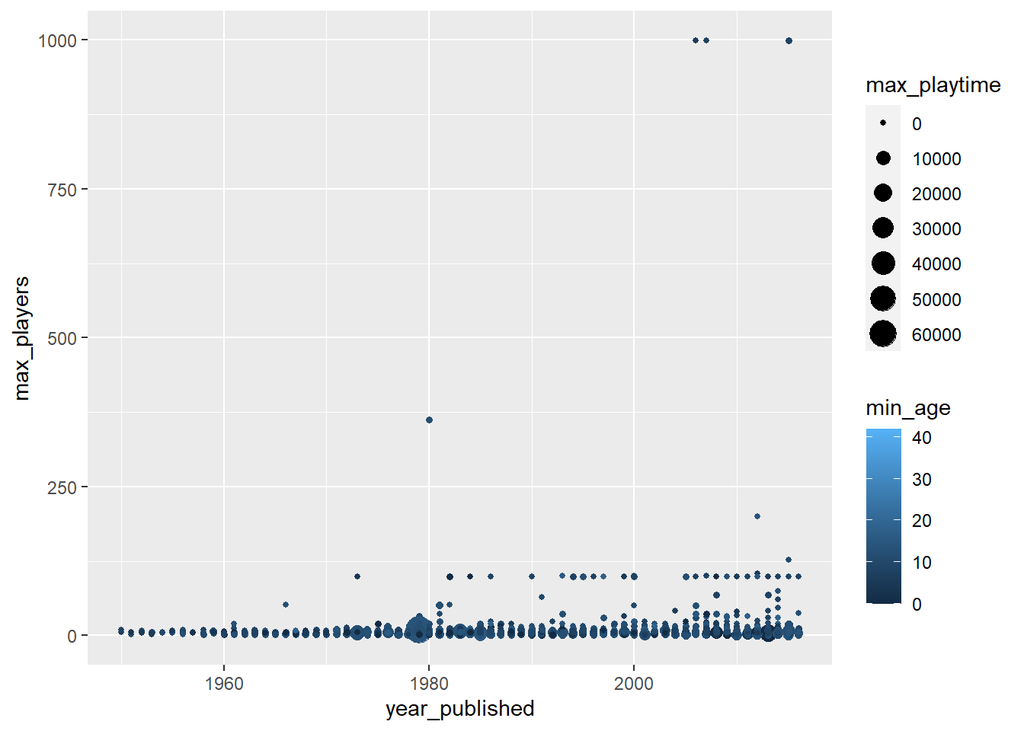

```r
board_games %>%
  ggplot(mapping = aes(x = year_published, y = max_players, color = min_age, size = max_playtime)) +
  geom_point()
```

## All done!

Knit the completed R Markdown file as a HTML document (click the “Knit” button at the top of the editor window) and upload it to Canvas.